# Quantitative Methods – Day 2: Other Regression Issues

Harm H. Schuett

05 January, 2018

```r
library(ggplot2)
```

> The problem is that regression is like a demon or djinn from folktale. It answers exactly that question that you asked it. Often you don’t realize though that you asked the wrong question ~ paraphrasing Richard McElreath

# 1 Interactions

Often you see something that is called an interaction in regressions:

$$y_i = a_0 + a_1 x_i + a_2 d_i + a_3 x_i c_i + u_i$$

where $d_i$ is a dummy variable that separates the sample observations into two groups and only takes on one of two values: either a 1 if it belongs to group one and 0 if it belongs to the other group.

The purpose of such creating such a dummy variable and fitting a regression as the one above is to:

1. Allow for different regression slopes for each group.
2. Provide and easy test for whether the difference between slopes is statistically significant.

```r
set.seed(2345)
n <- 100
d <- rbinom(n=n, size=1, prob=0.5)
x <- rnorm(n=n, mean=3, sd=1)
u <- rnorm(n=n, mean=0, sd=1)
y <- ifelse(d == 1,
            1 + 2 * x + u,
            4 - 0.5 * x + u)
par(mfrow=c(1,2))
# just the points
plot(x, y, col=cblue, pch=20)
# showing group 1 and group 2
plot(x, y, col=cblue, pch=20)
```

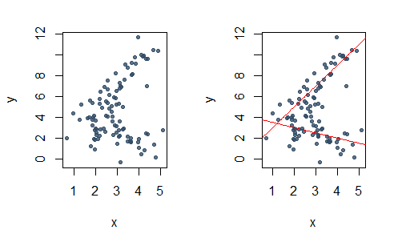

```r
curve(1 + 2 * x, from=0, to=6, add=TRUE, col="red")
curve(4 + -0.5 * x, from=0, to=6, add=TRUE, col="red")
```

How would this look like in a regression?

```r
summary(lm(y ~ x*d))
```

```
Call:
lm(formula = y ~ x * d)

Residuals:
     Min       1Q   Median       3Q      Max
-2.89433 -0.50642 -0.08248  0.73439  2.77748

Coefficients:
            Estimate Std. Error t value Pr(>|t|)
(Intercept)   4.1914     0.4924   8.512 2.32e-13 ***
x            -0.5837     0.1592  -3.665 0.000405 ***
d            -4.0203     0.7327  -5.487 3.32e-07 ***
x:d           2.7850     0.2355  11.824  < 2e-16 ***
---
Signif. codes:  0 ‘***’ 0.001 ‘**’ 0.01 ‘*’ 0.05 ‘.’ 0.1 ‘ ’ 1

Residual standard error: 1.097 on 96 degrees of freedom
Multiple R-squared:  0.8527,    Adjusted R-squared:  0.8481
F-statistic: 185.2 on 3 and 96 DF,  p-value: < 2.2e-16
```

We will see interactions everywhere, so make sure you understand the rationale and interpretation.

## 1.1 An example

Take the rugged example from Richard McElreath’s fantastic [book](https://github.com/rmcelreath/rethinking)

```r
rugged <- read.csv("../data/rugged.csv", sep=";")
# make log version of outcome
rugged$log_gdp <- log(rugged$rgdppc_2000)
# extract countries with GDP data
rugged <- rugged[complete.cases(rugged$rgdppc_2000), ]
```

This is data from the study Nunn and Puga (2012) [(here)](https://scholar.harvard.edu/nunn/publications/ruggedness-blessing-bad-geography-africa). An often discussed question is whether terrain ruggedness hampers economic growht. If you plot terrain ruggedness against economic output, you get:

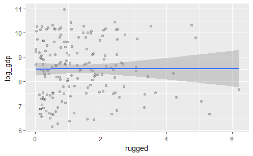

```r
ggplot(data=rugged, aes(x=rugged, y=log_gdp)) +
  geom_point(alpha=0.2) +
  geom_smooth(method="lm")
```

But, if you include a dummy interaction for whether a country is in africa or not, you get

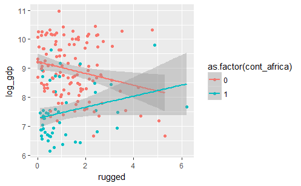

```r
ggplot(data=rugged, aes(x=rugged, y=log_gdp, color=as.factor(cont_africa))) +
  geom_point() +
  geom_smooth(method="lm")
```

```r
rmod <- lm(log_gdp ~ rugged*cont_africa, data=rugged)
summary(rmod)
```

```
Call:
lm(formula = log_gdp ~ rugged * cont_africa, data = rugged)

Residuals:
     Min       1Q   Median       3Q      Max
-2.08281 -0.74058 -0.05768  0.83096  2.24667

Coefficients:
                   Estimate Std. Error t value Pr(>|t|)
(Intercept)         9.22323    0.13965  66.044  < 2e-16 ***
rugged             -0.20286    0.07739  -2.621  0.00958 **
cont_africa        -1.94805    0.22726  -8.572 6.79e-15 ***
rugged:cont_africa  0.39339    0.13163   2.989  0.00323 **
---
Signif. codes:  0 ‘***’ 0.001 ‘**’ 0.01 ‘*’ 0.05 ‘.’ 0.1 ‘ ’ 1

Residual standard error: 0.9438 on 166 degrees of freedom
Multiple R-squared:  0.3569,    Adjusted R-squared:  0.3453
F-statistic: 30.71 on 3 and 166 DF,  p-value: 7.595e-16
```

How do you interpret it and what might be the reason for the seemingly differtn behavior of African countries?

# 2 Colinearity

$x$-variables are almost always correlated with each other. This makes coefficient estimates less precise. The extreme is variables which are perfectly correlated. That is equivalent to saying that one variable is a linear function of one or more of the remaining variables. In that case, OLS breaks down because you cannot compute the inverse $(X'X)^{-1}$ anymore. But it is also not surprising that it breaks down. If one variable is a linear function of other variables, then the same must be true for its coefficient – one should also be a linear function of the other coefficients. This means there are infinitely many coefficient combinations possible, no unique solution exists and OLS breaks down. Essentially, OLS does not know which variable it should allocate the effect to. Many solutions give you the same best fit. The problem is not so severe if variables are simply correlated, but it makes the allocation “less certain” Say you have two variables $x_1$ and $x_2$. Both move in tandem quite often and with $y$. When $x_1$ goes up, so does $x_2$ and $y$. Then it is hard to figure out, whether it is $x_1$ or $y$ that is associated with $y$. Essentially OLS tries to separate the impact of $x_1$ and $x_2$ from the few observations where $x_1$ and $x_2$ do not move similarly. If that does not happen often, the estimates are more uncertain because you have essentially a small sample size with different movements. If it never happens you have perfect co-linearity and OLS breaks down.

What this means in practice is that our $\hat{\beta}$ are less precisely estimated (we are more likely to get extreme estimates) and high standard errors. Remember the representation of our estimates:

$$E[\hat{\beta}] = E[\beta + (X'X)^{-1}X'u]$$

If the different $x_1$, $x_2$, $x_3$, .. variables in $X$ are correlated, $(X'X)^{-1}$ gets bigger. And you have more variation on the dart board:

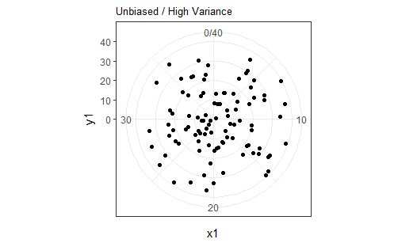

```r
df <- data.frame(x1 = runif(100, min=0, max=40),
                 y1 = runif(100, min=0, max=40))
ggplot(data=df, aes(x1, y1)) +
  geom_point() +
  coord_polar() +
  scale_y_continuous(limits=c(0, 40)) +
  scale_x_continuous(limits=c(0, 40))+
  labs(subtitle="Unbiased / High Variance") +
  theme_bw()
```

## 2.1 Examples

Maybe this is easiest to see via simulation:

```r
set.seed(666)
n <- 100
x1 <- rnorm(n=n, mean=1, sd=2)
x2a <- rnorm(n=n, mean=3, sd=2)
x2b <- x2a + 2.9 * x1
u <- rnorm(n=n, mean=0, sd=2)
ya <- 1 + 2*x1 - 2*x2a + u
yb <- 1 + 2*x1 - 2*x2b + u
fit_a <- lm(ya ~ x1 + x2a)
fit_b <- lm(yb ~ x1 + x2b)
summary(fit_a)
```

```
Call:
lm(formula = ya ~ x1 + x2a)

Residuals:
    Min      1Q  Median      3Q     Max
-4.9179 -1.1798 -0.0092  1.2974  4.3092

Coefficients:
            Estimate Std. Error t value Pr(>|t|)
(Intercept)  0.75614    0.32436   2.331   0.0218 *
x1           1.97731    0.10000  19.772   <2e-16 ***
x2a         -1.96955    0.09067 -21.722   <2e-16 ***
---
Signif. codes:  0 ‘***’ 0.001 ‘**’ 0.01 ‘*’ 0.05 ‘.’ 0.1 ‘ ’ 1

Residual standard error: 2.015 on 97 degrees of freedom
Multiple R-squared:  0.8829,    Adjusted R-squared:  0.8805
F-statistic: 365.6 on 2 and 97 DF,  p-value: < 2.2e-16
```

```r
summary(fit_b)
```

```
Call:
lm(formula = yb ~ x1 + x2b)

Residuals:
    Min      1Q  Median      3Q     Max
-4.9179 -1.1798 -0.0092  1.2974  4.3092

Coefficients:
            Estimate Std. Error t value Pr(>|t|)
(Intercept)  0.75614    0.32436   2.331   0.0218 *
x1           1.88901    0.29776   6.344 7.14e-09 ***
x2b         -1.96955    0.09067 -21.722  < 2e-16 ***
---
Signif. codes:  0 ‘***’ 0.001 ‘**’ 0.01 ‘*’ 0.05 ‘.’ 0.1 ‘ ’ 1

Residual standard error: 2.015 on 97 degrees of freedom
Multiple R-squared:  0.9597,    Adjusted R-squared:  0.9589
F-statistic:  1155 on 2 and 97 DF,  p-value: < 2.2e-16
```

# 3 Measurement Error

## 3.1 The problem

A general problem you should be aware of is measurement error. Many of our constructs and concepts (sentiment, earnings quality, risk aversion, ability, financial constraints, marginal tax rate, happiness, customer satisfaction,etc.) are unobserved or hard to measure. We can try to find or create proxies. However, these will invariably measure our construct of interest with error. Think about all the textual analysis measures for sentiment, readability etc. For example, using the number of negative words as a measure of text tone. Obviously, this will not capture every nuance; it will contain significant measurement error of the real tone of the text.

Depending on the amount of measurement error, proxies are like a broad sword as compared to a scalpel. It is fine for research questions where you are after broad effects. But you have to be careful with questions that require a scalpel. In those cases, you absolutely need to be concerned about measurement error.

## 3.2 Mathematical presentation of the problem

There is a good treatment in Wooldridge (2010) pp.70. The following is a short summary.

Imagine a regression of the form $y = a_0 + a_1 x_1 + a_2 x_2 + a_3 x^*_3 + u$, but we cannot observe $x^*_3$. Instead, we have a measure $x_3$. For example, think of $x^*_3$ as happiness and $x_3$ as a measure derived from survey questions.

We assume $x_3$ measures $x^*_3$ with error $e_3 = x_3 - x^*_3$. We substitute this equation into the above formula and get:

$$y = a_0 + a_1 x_1 + a_2 x_2 + a_3 x_3 + (u - a_3e_3)$$

The measurement error moves into the error term. Because the measurement error lurks in the error term, you get something very similar to a correlated omitted variables problem, if the measurement error is correlated with $x_3$. In quite a few cases this is likely.

Let’s assume the average measurement error is zero $E[e_3]=0$ (not a very consequential assumption because of the intercept in our regressions). The **classical errors-in-variables (CEV)** assumption is that the measurement error is uncorrelated with the true unobserved variable:

$$cov(x^*_3, e_3)=0$$

If we write $x_3 = x^*_3 + e_3$ (the measure is the true variable plus error) and $cov(x^*_3, e_3)=0$, this means that $cov(x_3, e_3)$ must be non-zero:

$$cov(x_3, e_3) = E[x_3e_3] = E[(x^*_3+e_3)e_3] = E[x^*_3e_3] + E[e^2_3] = \sigma^2_{e_3}$$

since $E[x^*_3e_3] = 0$ by the CEV assumption. Thus $cov(x_3, e_3)=\sigma^2_{e_3}$ the variance of the measurement error. Now, because the measurement error lurks in the error term, you get something very similar to a correlated omitted variables problem. The correlation of $x_3$ with the error term is thus $-a_3\sigma^2_{e_3}$.

In this case, the regression of $y$ on $x_1$, $x_2$, and $x_3$, we generally have inconsistent estimators of **all** estimators of all coefficients if $x^*_3$ is correlated with the other variables in the regressio. Then, it is hard to figure out the bias. if $x^*_3$ is uncorrelated with $x_1$ and $x_2$, then so is $x_3$. Then only $a_3$ is biased. The bias for $a_3$ is **always an attenuation bias** because the correlation of $x_3$ with the error term is $-a_3\sigma^2_{e_3}$

# 4 References

Nunn, Nathan, and Diego Puga. 2012. “Ruggedness: The Blessing of Bad Geography in Africa.” *Review of Economics and Statistics* 94 (1): 20–36.

Wooldridge, Jeffrey M. 2010. *Econometric Analysis of Cross Section and Panel Data*. MIT Press.